# Homework 1

Given the formulated question from the assignment description, you will now conduct EDA Checklist items 1-5. First, download 2002 and 2022 data for all sites in California from the EPA Air Quality Data website.

## Step 1

Read the data into R. For each of the two datasets, check the dimensions, headers, footers, variable names and variable types. Check the distribution of the key variable we are analyzing (PM 2.5). Write up a summary of all of your findings.

# Summary

- EPA_2002: 15,976 rows × 22 columns EPA_2022: 59,918 rows × 22 columns
  - The 2022 dataset contains ~4× more observations than 2002.This difference reflects more monitors, complete daily reporting, and expanded surveillance in California over time.
  - Both datasets load cleanly with no header/footer lines,the first/last rows appear to be valid daily observations.
  - Both datasets contain 22 variables, including: Date (character), Site ID (character), Daily Mean PM2.5 Concentration (numeric), Daily AQI Value (numeric), Local Site Name (character), State, County (character),Site Latitude, and Site Longitude (numeric).
  - PM2.5 concentrations in 2002 show a higher median, greater spread, and more extreme values compared to 2022. The 2022 distribution is substantially lower and tighter.

```r
# Paths to downloaded CSVs (Daily Summary PM2.5)
library(readr)
EPA_2002 <- read_csv("~/PM 556/PM556-/HW 1/EPA_2002.csv", col_names = TRUE)
EPA_2022 <- read_csv("~/PM 556/PM556-/HW 1/EPA_2022.csv", col_names = TRUE)
# Dimensions, Header, Footer and Structure
dim(EPA_2002)
```

```
[1] 15976    22
```

```r
dim(EPA_2022)
```

```
[1] 59918    22
```

```r
head(EPA_2002)
```

```
# A tibble: 6 × 22
  Date     Source `Site ID`   POC Daily Mean PM2.5 Con…¹ Units `Daily AQI Value`
  <chr>    <chr>  <chr>     <dbl>                  <dbl> <chr>             <dbl>
1 01/05/2… AQS    060010007     1                   25.1 ug/m…                81
2 01/06/2… AQS    060010007     1                   31.6 ug/m…                93
3 01/08/2… AQS    060010007     1                   21.4 ug/m…                74
4 01/11/2… AQS    060010007     1                   25.9 ug/m…                82
5 01/14/2… AQS    060010007     1                   34.5 ug/m…                98
6 01/17/2… AQS    060010007     1                   41   ug/m…               115
# ℹ abbreviated name: ¹`Daily Mean PM2.5 Concentration`
# ℹ 15 more variables: `Local Site Name` <chr>, `Daily Obs Count` <dbl>,
#   `Percent Complete` <dbl>, `AQS Parameter Code` <dbl>,
#   `AQS Parameter Description` <chr>, `Method Code` <dbl>,
#   `Method Description` <chr>, `CBSA Code` <dbl>, `CBSA Name` <chr>,
#   `State FIPS Code` <chr>, State <chr>, `County FIPS Code` <chr>,
#   County <chr>, `Site Latitude` <dbl>, `Site Longitude` <dbl>
```

```r
tail(EPA_2002)
```

```
# A tibble: 6 × 22
  Date     Source `Site ID`   POC Daily Mean PM2.5 Con…¹ Units `Daily AQI Value`
  <chr>    <chr>  <chr>     <dbl>                  <dbl> <chr>             <dbl>
1 12/10/2… AQS    061131003     1                     15 ug/m…                62
2 12/13/2… AQS    061131003     1                     15 ug/m…                62
3 12/22/2… AQS    061131003     1                      1 ug/m…                 6
4 12/25/2… AQS    061131003     1                     23 ug/m…                77
5 12/28/2… AQS    061131003     1                      5 ug/m…                28
6 12/31/2… AQS    061131003     1                      6 ug/m…                33
# ℹ abbreviated name: ¹`Daily Mean PM2.5 Concentration`
# ℹ 15 more variables: `Local Site Name` <chr>, `Daily Obs Count` <dbl>,
#   `Percent Complete` <dbl>, `AQS Parameter Code` <dbl>,
#   `AQS Parameter Description` <chr>, `Method Code` <dbl>,
#   `Method Description` <chr>, `CBSA Code` <dbl>, `CBSA Name` <chr>,
#   `State FIPS Code` <chr>, State <chr>, `County FIPS Code` <chr>,
#   County <chr>, `Site Latitude` <dbl>, `Site Longitude` <dbl>
```

```r
head(EPA_2022)
```

```
# A tibble: 6 × 22
  Date     Source `Site ID`   POC Daily Mean PM2.5 Con…¹ Units `Daily AQI Value`
  <chr>    <chr>  <chr>     <dbl>                  <dbl> <chr>             <dbl>
1 01/01/2… AQS    060010007     3                   12.7 ug/m…                58
2 01/02/2… AQS    060010007     3                   13.9 ug/m…                60
3 01/03/2… AQS    060010007     3                    7.1 ug/m…                39
4 01/04/2… AQS    060010007     3                    3.7 ug/m…                21
5 01/05/2… AQS    060010007     3                    4.2 ug/m…                23
6 01/06/2… AQS    060010007     3                    3.8 ug/m…                21
# ℹ abbreviated name: ¹`Daily Mean PM2.5 Concentration`
# ℹ 15 more variables: `Local Site Name` <chr>, `Daily Obs Count` <dbl>,
#   `Percent Complete` <dbl>, `AQS Parameter Code` <dbl>,
#   `AQS Parameter Description` <chr>, `Method Code` <dbl>,
#   `Method Description` <chr>, `CBSA Code` <dbl>, `CBSA Name` <chr>,
#   `State FIPS Code` <chr>, State <chr>, `County FIPS Code` <chr>,
#   County <chr>, `Site Latitude` <dbl>, `Site Longitude` <dbl>
```

```r
tail(EPA_2022)
```

```
# A tibble: 6 × 22
  Date     Source `Site ID`   POC Daily Mean PM2.5 Con…¹ Units `Daily AQI Value`
  <chr>    <chr>  <chr>     <dbl>                  <dbl> <chr>             <dbl>
1 12/01/2… AQS    061131003     1                    3.4 ug/m…                19
2 12/07/2… AQS    061131003     1                    3.8 ug/m…                21
3 12/13/2… AQS    061131003     1                    6   ug/m…                33
4 12/19/2… AQS    061131003     1                   34.8 ug/m…                99
5 12/25/2… AQS    061131003     1                   23.2 ug/m…                77
6 12/31/2… AQS    061131003     1                    1   ug/m…                 6
# ℹ abbreviated name: ¹`Daily Mean PM2.5 Concentration`
# ℹ 15 more variables: `Local Site Name` <chr>, `Daily Obs Count` <dbl>,
#   `Percent Complete` <dbl>, `AQS Parameter Code` <dbl>,
#   `AQS Parameter Description` <chr>, `Method Code` <dbl>,
#   `Method Description` <chr>, `CBSA Code` <dbl>, `CBSA Name` <chr>,
#   `State FIPS Code` <chr>, State <chr>, `County FIPS Code` <chr>,
#   County <chr>, `Site Latitude` <dbl>, `Site Longitude` <dbl>
```

```r
str(EPA_2002)
```

```
spc_tbl_ [15,976 × 22] (S3: spec_tbl_df/tbl_df/tbl/data.frame)
 $ Date                          : chr [1:15976] "01/05/2002" "01/06/2002" "01/08/2002" "01/11/2002" ...
 $ Source                        : chr [1:15976] "AQS" "AQS" "AQS" "AQS" ...
 $ Site ID                       : chr [1:15976] "060010007" "060010007" "060010007" "060010007" ...
 $ POC                           : num [1:15976] 1 1 1 1 1 1 1 1 1 1 ...
 $ Daily Mean PM2.5 Concentration: num [1:15976] 25.1 31.6 21.4 25.9 34.5 41 29.3 15 18.8 37.9 ...
 $ Units                         : chr [1:15976] "ug/m3 LC" "ug/m3 LC" "ug/m3 LC" "ug/m3 LC" ...
 $ Daily AQI Value               : num [1:15976] 81 93 74 82 98 115 89 62 69 107 ...
 $ Local Site Name               : chr [1:15976] "Livermore" "Livermore" "Livermore" "Livermore" ...
 $ Daily Obs Count               : num [1:15976] 1 1 1 1 1 1 1 1 1 1 ...
 $ Percent Complete              : num [1:15976] 100 100 100 100 100 100 100 100 100 100 ...
 $ AQS Parameter Code            : num [1:15976] 88101 88101 88101 88101 88101 ...
 $ AQS Parameter Description     : chr [1:15976] "PM2.5 - Local Conditions" "PM2.5 - Local Conditions" "PM2.5 - Local Conditions" "PM2.5 - Local Conditions" ...
 $ Method Code                   : num [1:15976] 120 120 120 120 120 120 120 120 120 120 ...
 $ Method Description            : chr [1:15976] "Andersen RAAS2.5-300 PM2.5 SEQ w/WINS" "Andersen RAAS2.5-300 PM2.5 SEQ w/WINS" "Andersen RAAS2.5-300 PM2.5 SEQ w/WINS" "Andersen RAAS2.5-300 PM2.5 SEQ w/WINS" ...
 $ CBSA Code                     : num [1:15976] 41860 41860 41860 41860 41860 ...
 $ CBSA Name                     : chr [1:15976] "San Francisco-Oakland-Hayward, CA" "San Francisco-Oakland-Hayward, CA" "San Francisco-Oakland-Hayward, CA" "San Francisco-Oakland-Hayward, CA" ...
 $ State FIPS Code               : chr [1:15976] "06" "06" "06" "06" ...
 $ State                         : chr [1:15976] "California" "California" "California" "California" ...
 $ County FIPS Code              : chr [1:15976] "001" "001" "001" "001" ...
 $ County                        : chr [1:15976] "Alameda" "Alameda" "Alameda" "Alameda" ...
 $ Site Latitude                 : num [1:15976] 37.7 37.7 37.7 37.7 37.7 ...
 $ Site Longitude                : num [1:15976] -122 -122 -122 -122 -122 ...
 - attr(*, "spec")=
  .. cols(
  ..   Date = col_character(),
  ..   Source = col_character(),
  ..   `Site ID` = col_character(),
  ..   POC = col_double(),
  ..   `Daily Mean PM2.5 Concentration` = col_double(),
  ..   Units = col_character(),
  ..   `Daily AQI Value` = col_double(),
  ..   `Local Site Name` = col_character(),
  ..   `Daily Obs Count` = col_double(),
  ..   `Percent Complete` = col_double(),
  ..   `AQS Parameter Code` = col_double(),
  ..   `AQS Parameter Description` = col_character(),
  ..   `Method Code` = col_double(),
  ..   `Method Description` = col_character(),
  ..   `CBSA Code` = col_double(),
  ..   `CBSA Name` = col_character(),
  ..   `State FIPS Code` = col_character(),
  ..   State = col_character(),
  ..   `County FIPS Code` = col_character(),
  ..   County = col_character(),
  ..   `Site Latitude` = col_double(),
  ..   `Site Longitude` = col_double()
  .. )
 - attr(*, "problems")=<pointer: 0x00000294ea1febe0>
```

```r
str(EPA_2022)
```

```
spc_tbl_ [59,918 × 22] (S3: spec_tbl_df/tbl_df/tbl/data.frame)
 $ Date                          : chr [1:59918] "01/01/2022" "01/02/2022" "01/03/2022" "01/04/2022" ...
 $ Source                        : chr [1:59918] "AQS" "AQS" "AQS" "AQS" ...
 $ Site ID                       : chr [1:59918] "060010007" "060010007" "060010007" "060010007" ...
 $ POC                           : num [1:59918] 3 3 3 3 3 3 3 3 3 3 ...
 $ Daily Mean PM2.5 Concentration: num [1:59918] 12.7 13.9 7.1 3.7 4.2 3.8 2.3 6.9 13.6 11.2 ...
 $ Units                         : chr [1:59918] "ug/m3 LC" "ug/m3 LC" "ug/m3 LC" "ug/m3 LC" ...
 $ Daily AQI Value               : num [1:59918] 58 60 39 21 23 21 13 38 59 55 ...
 $ Local Site Name               : chr [1:59918] "Livermore" "Livermore" "Livermore" "Livermore" ...
 $ Daily Obs Count               : num [1:59918] 1 1 1 1 1 1 1 1 1 1 ...
 $ Percent Complete              : num [1:59918] 100 100 100 100 100 100 100 100 100 100 ...
 $ AQS Parameter Code            : num [1:59918] 88101 88101 88101 88101 88101 ...
 $ AQS Parameter Description     : chr [1:59918] "PM2.5 - Local Conditions" "PM2.5 - Local Conditions" "PM2.5 - Local Conditions" "PM2.5 - Local Conditions" ...
 $ Method Code                   : num [1:59918] 170 170 170 170 170 170 170 170 170 170 ...
 $ Method Description            : chr [1:59918] "Met One BAM-1020 Mass Monitor w/VSCC" "Met One BAM-1020 Mass Monitor w/VSCC" "Met One BAM-1020 Mass Monitor w/VSCC" "Met One BAM-1020 Mass Monitor w/VSCC" ...
 $ CBSA Code                     : num [1:59918] 41860 41860 41860 41860 41860 ...
 $ CBSA Name                     : chr [1:59918] "San Francisco-Oakland-Hayward, CA" "San Francisco-Oakland-Hayward, CA" "San Francisco-Oakland-Hayward, CA" "San Francisco-Oakland-Hayward, CA" ...
 $ State FIPS Code               : chr [1:59918] "06" "06" "06" "06" ...
 $ State                         : chr [1:59918] "California" "California" "California" "California" ...
 $ County FIPS Code              : chr [1:59918] "001" "001" "001" "001" ...
 $ County                        : chr [1:59918] "Alameda" "Alameda" "Alameda" "Alameda" ...
 $ Site Latitude                 : num [1:59918] 37.7 37.7 37.7 37.7 37.7 ...
 $ Site Longitude                : num [1:59918] -122 -122 -122 -122 -122 ...
 - attr(*, "spec")=
  .. cols(
  ..   Date = col_character(),
  ..   Source = col_character(),
  ..   `Site ID` = col_character(),
  ..   POC = col_double(),
  ..   `Daily Mean PM2.5 Concentration` = col_double(),
  ..   Units = col_character(),
  ..   `Daily AQI Value` = col_double(),
  ..   `Local Site Name` = col_character(),
  ..   `Daily Obs Count` = col_double(),
  ..   `Percent Complete` = col_double(),
  ..   `AQS Parameter Code` = col_double(),
  ..   `AQS Parameter Description` = col_character(),
  ..   `Method Code` = col_double(),
  ..   `Method Description` = col_character(),
  ..   `CBSA Code` = col_double(),
  ..   `CBSA Name` = col_character(),
  ..   `State FIPS Code` = col_character(),
  ..   State = col_character(),
  ..   `County FIPS Code` = col_character(),
  ..   County = col_character(),
  ..   `Site Latitude` = col_double(),
  ..   `Site Longitude` = col_double()
  .. )
 - attr(*, "problems")=<pointer: 0x00000294ea1fe920>
```

## Step 2

Combine the two years of data into one data frame. Use the Date variable to create a new column for year, which will serve as an identifier. Change the names of the key variables so that they are easier to refer to in your code.

```r
library(tidyverse)
library(lubridate)

# create a new column for year
EPA_2002 <- EPA_2002 %>%
  mutate(
    date = mdy(Date),
    pm25 = `Daily Mean PM2.5 Concentration`,
    year = 2002
  )

EPA_2022 <- EPA_2022 %>%
  mutate(
    date = mdy(Date),
    pm25 = `Daily Mean PM2.5 Concentration`,
    year = 2022
  )

# Combine both data into one data frame
pm_all <- bind_rows(EPA_2002, EPA_2022)

# Rename key variables for clarity
pm_all <- pm_all %>%
  rename(
    site_id = `Site ID`,
    site_name = `Local Site Name`,
    county = County,
    state = State,
    latitude = `Site Latitude`,
    longitude = `Site Longitude`
  )
```

## Step 3

Create a basic map (or maps) in either leaflet or ggplot showing the locations of the monitoring sites, using different colors for each year. Summarize the spatial distribution of the sites.

Does this distribution change from 2002 to 2022? - The map shows that PM2.5 monitoring sites in California are heavily clustered in major population centers, like San Francisco Bay Area, Los Angeles County, San Diego, and the Central Valley. Rural and mountainous regions and far northern counties, have fewer monitors in both years.

# Summary

- Comparing 2002 and 2022, the overall spatial distribution is similar, but 2022 shows a noticeably larger number of monitoring sites. This reflects increased regulatory attention and improved air quality surveillance in regions with historically elevated PM2.5 levels.

  Overall, the core urban clusters remain consistent, but the 2022 dataset displays broader coverage and denser monitoring networks across the state.

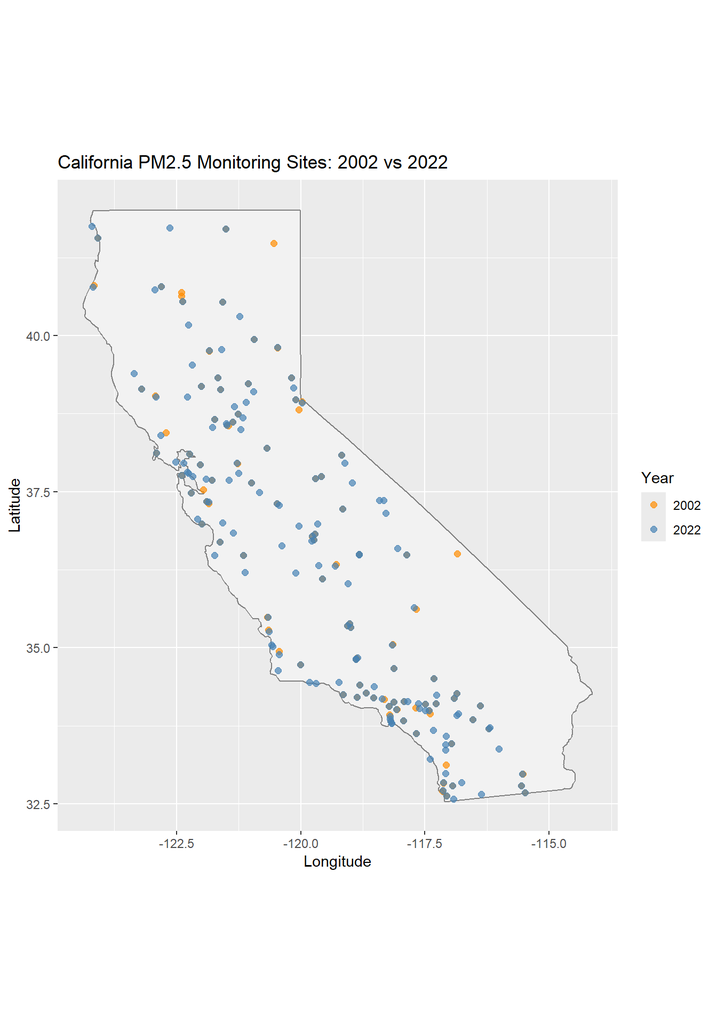

```r
# Extract unique site locations per year- each site once per year
sites <- pm_all %>%
  distinct(year, site_id, latitude, longitude)

#
library(ggplot2)
library(maps)
ggplot(sites, aes(x = longitude, y = latitude, color = factor(year))) +
  borders("state", regions = "california", fill = "gray95") +
  geom_point(size = 2, alpha = 0.7) +
  coord_quickmap() +
  scale_color_manual(values = c("2002" = "darkorange", "2022" = "steelblue")) +
  labs(
    title = "California PM2.5 Monitoring Sites: 2002 vs 2022",
    x = "Longitude",
    y = "Latitude",
    color = "Year"
  )
```

## Step 4

```r
# Check the data for any missing or implausible values
pm_all <- pm_all %>%
  mutate(
    pm25 = `Daily Mean PM2.5 Concentration`,
    pm_missing = is.na(pm25),
    pm_implausible = pm25 < 0 | pm25 > 500
  )

# Portions of missing/implausible data for both years
issues <- pm_all %>%
  group_by(year) %>%
  summarise(
    n = n(),
    prop_missing = mean(pm_missing),
    prop_implausible = mean(pm_implausible)
  )

issues
```

```
# A tibble: 2 × 4
   year     n prop_missing prop_implausible
  <dbl> <int>        <dbl>            <dbl>
1  2002 15976            0          0
2  2022 59918            0          0.00359
```

## Step 5

Explore the main question of interest at three different levels of spatial resolution. Create data visualizations (e.g. boxplots, histograms, line plots, violin plots) and summary statistics that best suit each level of the analysis. Be sure to write up explanations of what you observe at each level.

Level 1: State. Examine the primary question for the entire state. Level 2: County. Examine the primary question for every county in California. Level 3: City. Restrict the data to sites in Los Angeles county and examine the primary question for every site.